# Acp

nihel kaboubi

13 mars 2018

```r
library("FactoMineR")
library("factoextra")

data =read.csv("C:/Users/asus/Desktop/SEM 2/Machine learning/lab3/caravan-insurance-challenge.csv",sep=";",header = T)

data.acm=data[,7:35]
d=scale(data.acm)
```

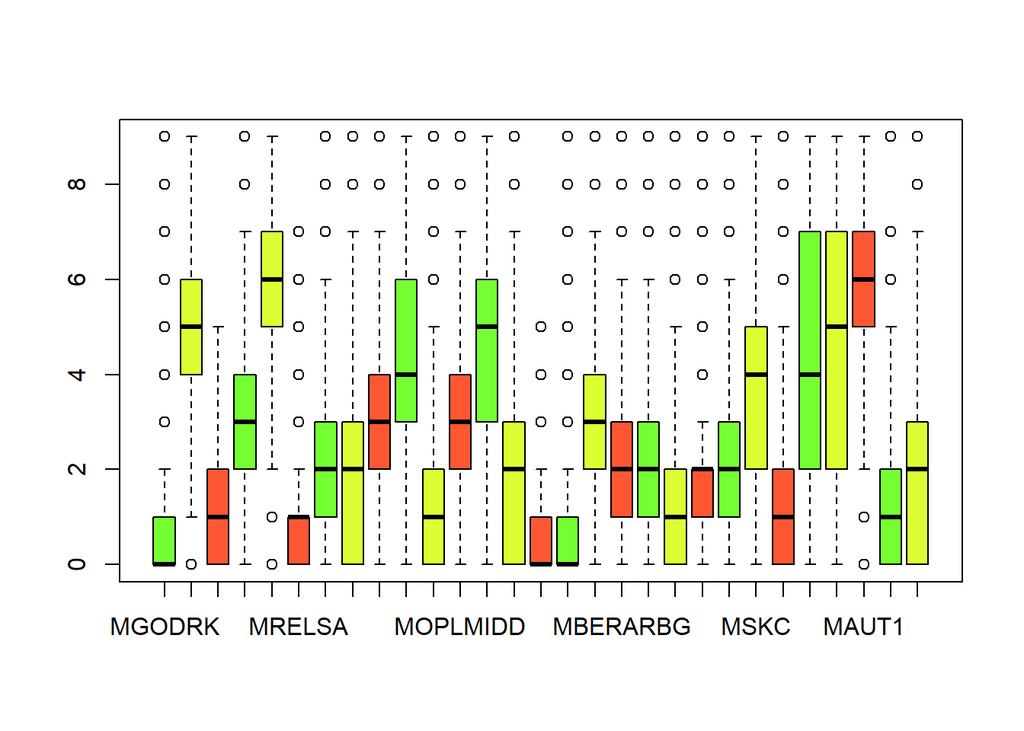

```r
boxplot(data[,7:35],col=c("#75FF33","#DBFF33","#FF5733"))
```

## MGODRK: Roman catholic /MGODPR: Protestant /MGODOV: Other religion/ MGODGE: No religion

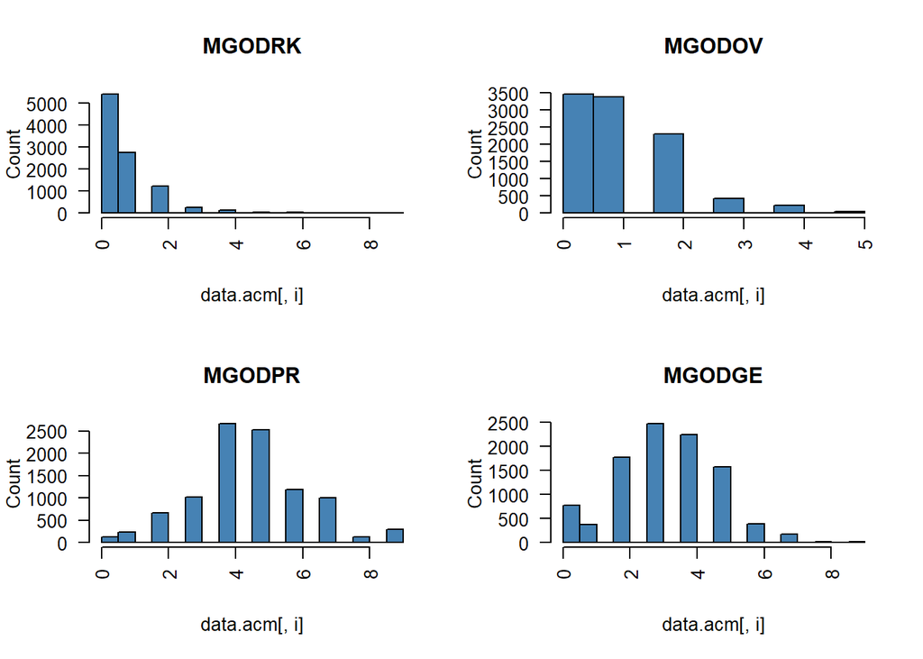

```r
###MGODRK: Roman catholic /MGODPR: Protestant /MGODOV: Other religion/ MGODGE: No religion
par(mfcol=c(2,2), pty="m", omi=c(0,0,0,0))
for (i in 1:4) {
  hist(data.acm[,i], main = colnames(data.acm)[i],
       ylab = "Count", col="steelblue", las = 2)
}
```

## MRELGE: Married/MRELSA: Living together/MRELOV: Other relation/ MFALLEEN: Singles

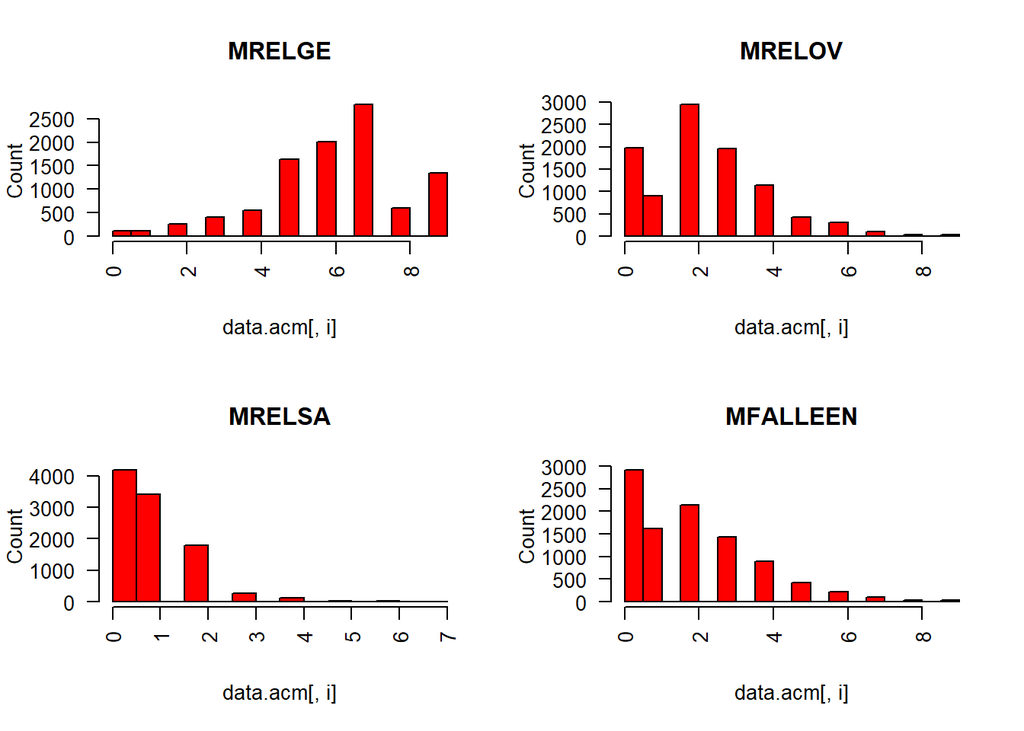

## MFGEKIND: Household without children/MFWEKIND: Household with children

## MOPLHOOG: High level education/MOPLMIDD: Medium level education//MOPLLAAG: Lower level education

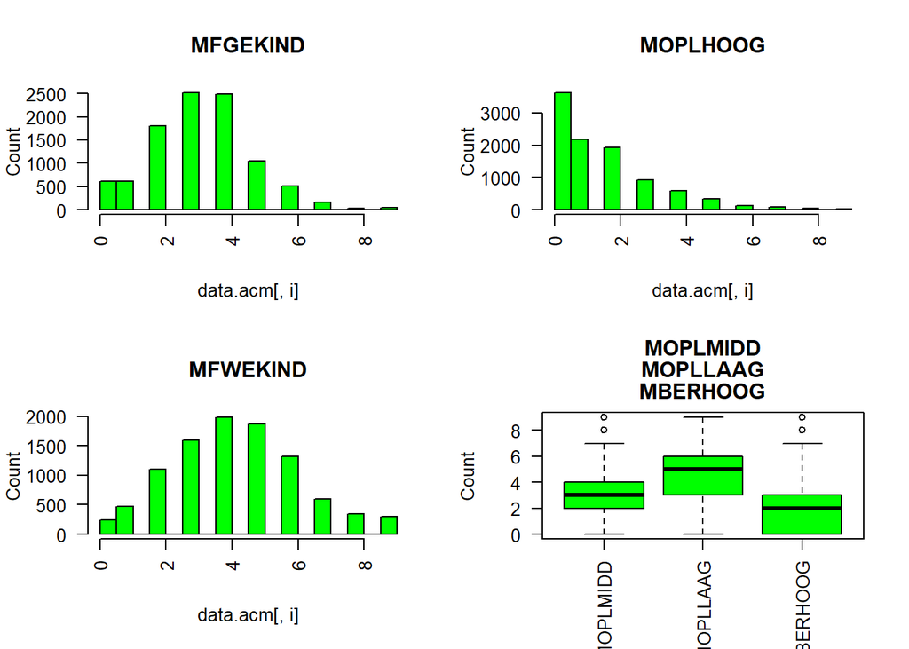

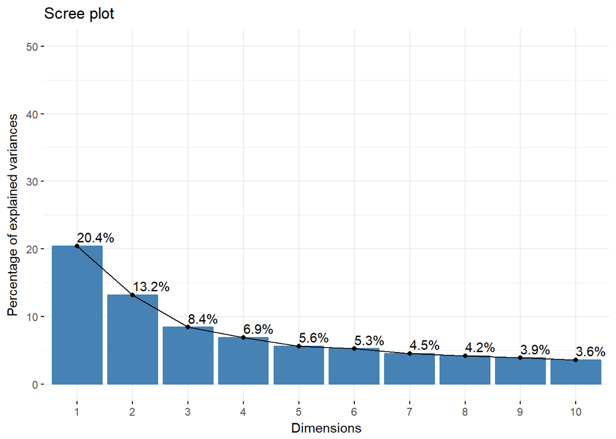

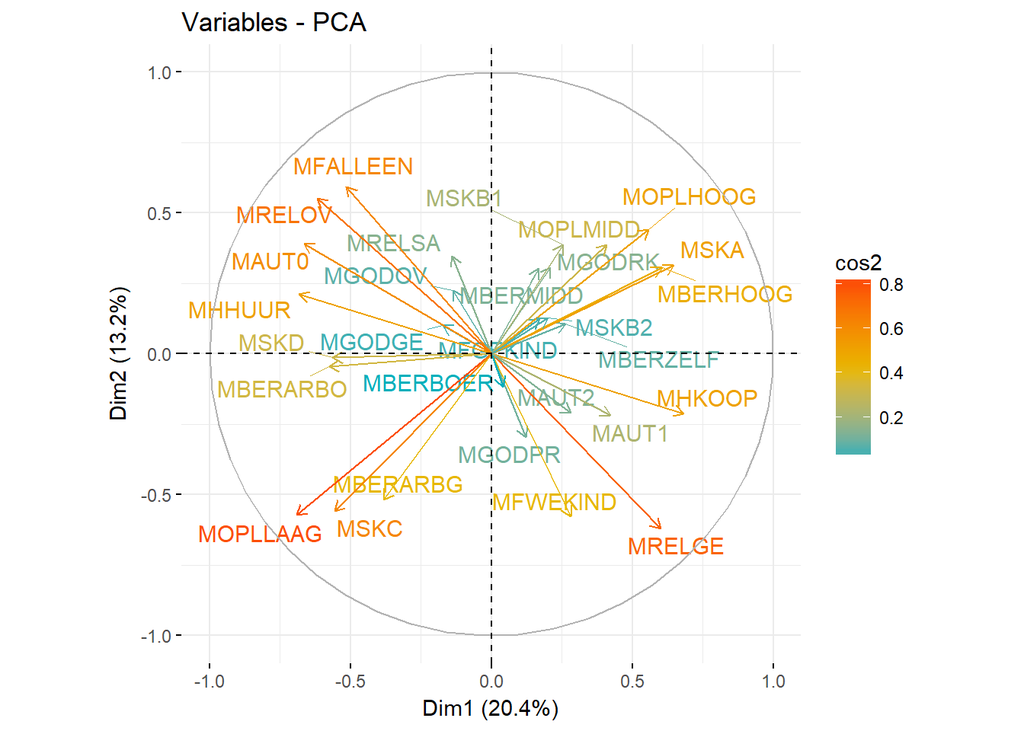

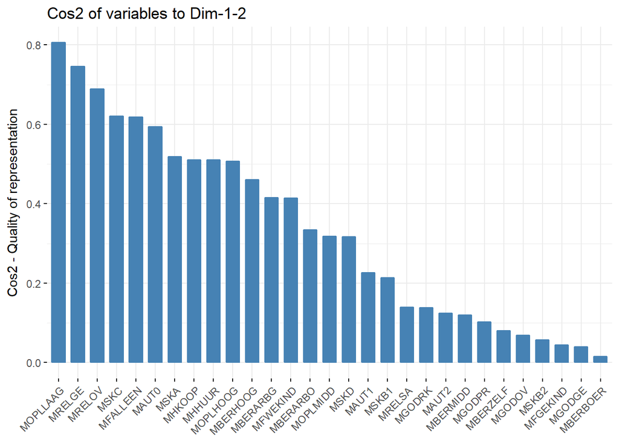

##analyse : #les deux premiers axes expriment environ 35% de l’inertie total #en d’autre terme, 35% de la variabilité totale du nuage des individus(ou des variables)est représenté par le premier plan(dim1+2) #ce pourcentage est acceptable vue le nomre imporatnt des variables à étudier.

## le premier axe :

# oppose les types de clients de classe bourgoise qui ont un bon niveau educatif avec ceux qui appartiennent à une classe sociale ouvriére qui a un bas niveau d éducation .